# compstats3

Problem 1 The density of the Beta(α, β)-distribution is given by π(x) ∝ (x^(α−1))*((1 − x)^(β−1)) for α > 0, β > 0 and 0 < x < 1.

1. For which values of α and β can adaptive rejection sampling be used for sampling from π? If α and β are both greater than or equal to 1, then π(x) is log concave and adaptive rejection sampling can be used. This result is explained below. If π(x) is log concave we can use adaptive rection sampling. π(x) is log concave if the first two derivatives of log(π(x)) exist and the second derivative is non-positive. We will calculate the first two derivatives of log(π(x))
   $$π(x) ∝ x^{α−1}*(1 − x)^{β−1}
   \\
   π(x) =Constant * x^{α−1}*(1 − x)^{β−1}
   \\
   log(π(x))=log(Constant) +(α−1)log(x) +(β−1)log(1-x)
   \\
   \frac{d}{dx}log(π(x))=\frac{α−1}{x} +\frac{-β+1}{1-x}
   \\
   \frac{d}{dx}(\frac{d}{dx}log(π(x)))=\frac{-α+1}{x^2} +\frac{-β+1}{(1-x)^2}$$
   Both the first and second derivative of log(π(x)) exist. And the second derivative is non-positive as long as α and β are both greater than or equal to 1. This is obvious since the denominator of both fractions in the second derivative will always be positive, if α=β=1 the expression will be 0 and if α and β are greater than or equal to 1 the expression will be 0 or negative. And thus the second derivative is always non-positive when α and β are greater than or equal to 1.
2. Install and load the package ars (for adaptive rejection sampling). Use the R-function ars of the package to generate n = 100, 000 random numbers from Beta(2, 6). Verify that it functions correctly by comparing the sample (kernel) density estimate to the true density function.

```r
require(ars)
```

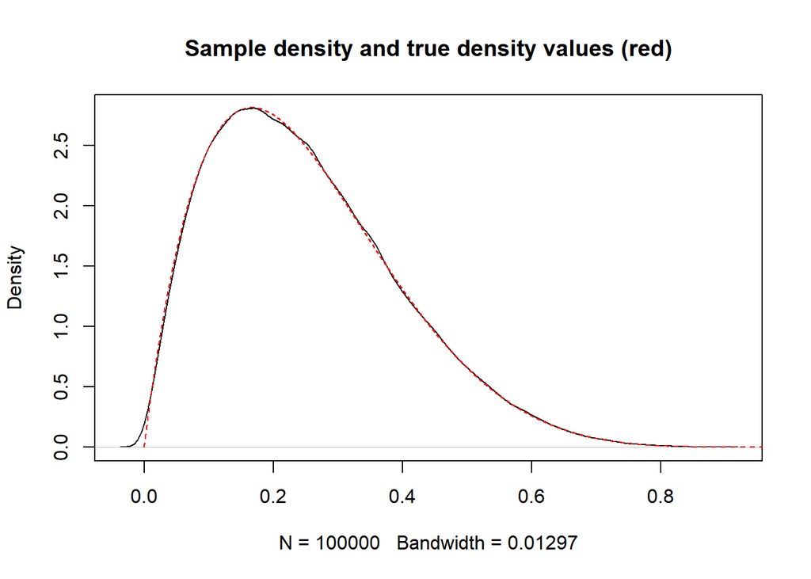

```r
#sample n values from a beta(al,be) distribution using ars
n<-100000
al<-2
be<-6
f<-function(x,a,b){(a-1)*log(x)+(b-1)*log(1-x)}
fprima<-function(x,a,b){(a-1)/x-(b-1)/(1-x)}
mysample<-ars(n,f,fprima,x=c(0.3,0.6),m=2,lb=TRUE,xlb=0,ub=TRUE,xub=1,a=al,b=be)


set.seed(1357)
plot(density(mysample), main="Sample density and true density values (red)")
x <- seq(0, 1, length=100000)
lines(x,dbeta(x,al,be),col="red",lty=2)
```

Problem 2 A new do-it-yourself HIV test is claimed to have 99% sensitivity and 98% specificity. Suppose that 0.1% of the population are infected with HIV. Note: “99% sensitivity” means that P(test positive|individual is HIV positive)=0.99; “98% specificity” means that P(test negative|individual is HIV negative)=0.98.

1. What is the probability that someone testing positive actually has HIV? We want the probability that the individual is HIV positive given that the test is positive. So we want to calculate P(individual is HIV positive|test positive) We will use Bayes Theorem, which says
   $$p(θ|x) = \frac{(x|θ)p(θ)}{f(x)}$$
   P(individual is HIV positive|test positive)=(P(test positive|individual is HIV positive)P(indidvidual is HIV positive))/P(test positive) P(indidvidual is HIV positive) = .1/100=.001 P(test positive|individual is HIV positive)=.99
   To solve this problem we need to calculate the probability of a positive test. We will do this using a system of equations. To start we will use abbreviations test positive = pos test negative = neg individual is HIV positive = H individual is HIV negative = nH We want to calculate P(H|pos) We’ll start with expressions we know from the problem description P(H)=.1/100=.001 P(nH)=1-P(H)=1-.001=.999 P(H|pos)+P(nH|pos)=1 P(H|neg)+P(nH|neg)=1 P(pos|H)+P(neg|H)=1 P(pos|nH)+P(neg|nH)=1 P(pos|H)=.99 P(neg|H)=1-.99=.01 P(neg|nH)=.98 P(pos|nH)=1-.98=.02 We know our expression for P(H|pos) P(H|pos)=(P(pos|H)P(H))/P(pos)=(.99*.001)/P(pos)=.00099/P(pos) Since we know P(H|pos)+P(nH|pos)=1, we can use P(nH|pos) to create a system of equations P(nH|pos)=(P(pos|nH)*P(nH))/P(pos)=((.02)*.999)/P(pos)=.01998/P(pos) P(nH|pos)=1-P(H|pos)=.01998/P(pos) So our two systems of equations are 1-P(H|pos)=.01998/P(pos) P(H|pos)=.00099/P(pos) Substituting and solving 1-(.00099/P(pos))=.01998/P(pos) 1=.02097/P(pos) P(pos)=.02097 P(H|pos)=.00099/P(pos)=.00099/.02097=.04727030042
2. What percentage of those testing positive do not have HIV? We want to caculate P(individual is HIV negative|test positive), we want P(nH|pos) P(nH|pos)=1-P(H|pos)=1-.04727030042=.95278969957

Problem 3 Suppose you have i.i.d. observations y1, y2, . . . , yn from Poi(λ). a) What is the maximum likelihood estimate of λ? likelihood(λ)=l(λ)=P(data|λ), the maximum likelihood estimate is the the value of λ that maximizes the likelihood. So it is the λ that maximizes P(y1, y2, . . . , yn|λ) Below we calculate the likelihood function
$$L(y_i|\lambda)=\prod_{i=1}^{n}f(y_i|\lambda)
\\
=\prod_{i=1}^{n}\frac{\lambda^{y_i}e^{-\lambda}}{y_{i}!}
\\$$
Now we want to take the log of the likelihood function to get the log likelihood
$$l(y_i|\lambda)=log(L(y_i|\lambda))=log(\prod_{i=1}^{n}\frac{\lambda^{y_i}e^{-\lambda}}{y_{i}!})
\\
=\sum_{i=1}^{n}log(\frac{\lambda^{y_i}e^{-\lambda}}{y_{i}!})
\\
=\sum_{i=1}^{n}log(\lambda^{y_i})+log(e^{-\lambda})-log(y_{i}!)
\\
=\sum_{i=1}^{n}y_{i}log(\lambda)-\lambda-log(y_{i}!)
\\
=-n\lambda +log(\lambda)\sum_{i=1}^{n}y_{i}-\sum_{i=1}^{n}log(y_{i}!)$$
Now we want to differentiate the log likelihood with respect to λ, as we want to find the value of λ that maximizes the log likelihood.
$$\frac{d}{d\lambda}l(y_i|\lambda)=\frac{d}{d\lambda}(-n\lambda +log(\lambda)\sum_{i=1}^{n}y_{i}-\sum_{i=1}^{n}log(y_{i}!))
\\
=-n+\frac{1}{\lambda}\sum_{i=1}^{n}y_{i}$$
Now we set the derivative of the log likelihood equal to 0 and solve to find the λ that maximizes our log likelihood, this value of λ is our maximum likelihood estimate.
$$\frac{d}{d\lambda}l(y_i|\lambda)=0
\\
-n+\frac{1}{\lambda}\sum_{i=1}^{n}y_{i}=0
\\
\lambda=\frac{1}{n}\sum_{i=1}^{n}y_{i}$$
We see that our maximum likelihood estimator for λ is the sample mean of the yi, it is the mean of the observations from Poi(λ)

2. Show that under a G(α, β)-prior the posterior of λ is again Gamma distributed and determine its parameters. The posterior is proportional to the product of likelihood and prior. We use the probability density function for the gamma distribution for our p(λ)
   $$p(\lambda|y)\propto p(\lambda)*l(\lambda)
   \\
   l(\lambda)=\prod_{i=1}^{n}\frac{\lambda^{y_i}e^{-\lambda}}{y_{i}!}\propto\frac{\lambda^{n\bar y}e^{-\lambda n}}{y_{1}!y_{2}!..y_{n}!}
   \\
   p(\lambda)=\frac{\beta^{\alpha}\lambda^{\alpha-1}e^{-\beta\lambda}}{\Gamma(\alpha)}
   \\
   p(\lambda|y)\propto\frac{\lambda^{n\bar y}e^{-\lambda n}}{y_{1}!y_{2}!..y_{n}!}\frac{\beta^{\alpha}\lambda^{\alpha-1}e^{-\beta\lambda}}{\Gamma(\alpha)}
   \\
   p(\lambda|y)\propto \frac{\beta^{\alpha}}{\Gamma(\alpha)y_{1}!y_{2}!..y_{n}!}\frac{e^{-\lambda(\beta+n)}}{\lambda^{(\alpha +n\bar y)-1}}
   \\$$
   We have shown the posterior is gamma distributed, the new parameters are
   $$\hat \beta=\beta +n
   \\
   \hat \alpha=\alpha+n \bar y$$
3. Use the R-function rpois to simulate n = 1000 observations from Poi(λ = 5). Further, assume a G(α = 70, β = 10)-prior on λ. Use your results from a) and b) to plot for the first 10, 100 and 1000 observations the prior density together with the resulting posterior density and the maximum likelihood estimate of λ.

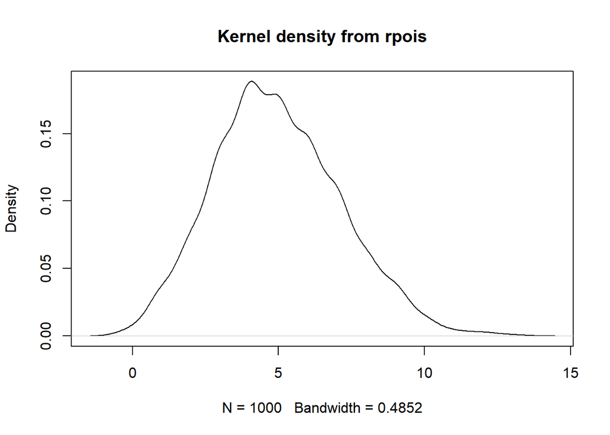

```r
set.seed(1357)
mysample <- rpois(1000, 5)
plot(density(mysample), main = "Kernel density from rpois")
```

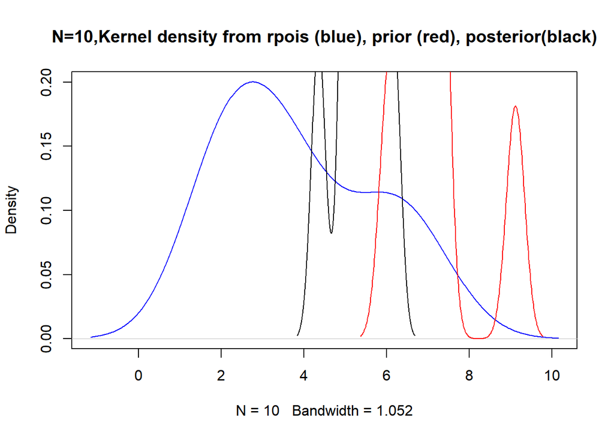

```r
#for n=10
n<-10
mysample10 <- rpois(n, 5)
maxlik10<-mean(mysample10)
#for gamma shape is alpha and scale is beta
myprior10 <- rgamma(n,70,10)
myposterior10<-rgamma(n,70+(n*maxlik10),10+n)
plot(density(mysample10),col="blue", main = "N=10,Kernel density from rpois (blue), prior (red), posterior(black)")
lines(density(myprior10),col="red")
lines(density(myposterior10),col="black")
```

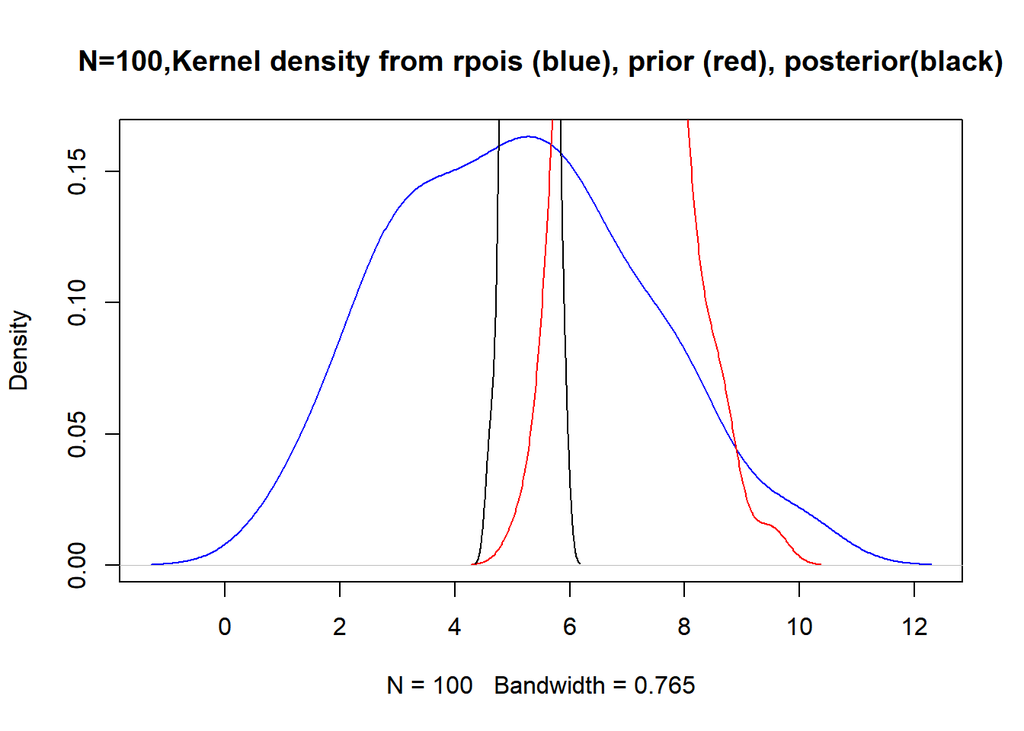

```r
#for n=100
n<-100
mysample100 <- rpois(n, 5)
maxlik100<-mean(mysample100)
#for gamma shape is alpha and scale is beta
myprior100 <- rgamma(n,70,10)
myposterior100<-rgamma(n,70+(n*maxlik100),10+n)
plot(density(mysample100),col="blue", main = "N=100,Kernel density from rpois (blue), prior (red), posterior(black)")
lines(density(myprior100),col="red")
lines(density(myposterior100),col="black")
```

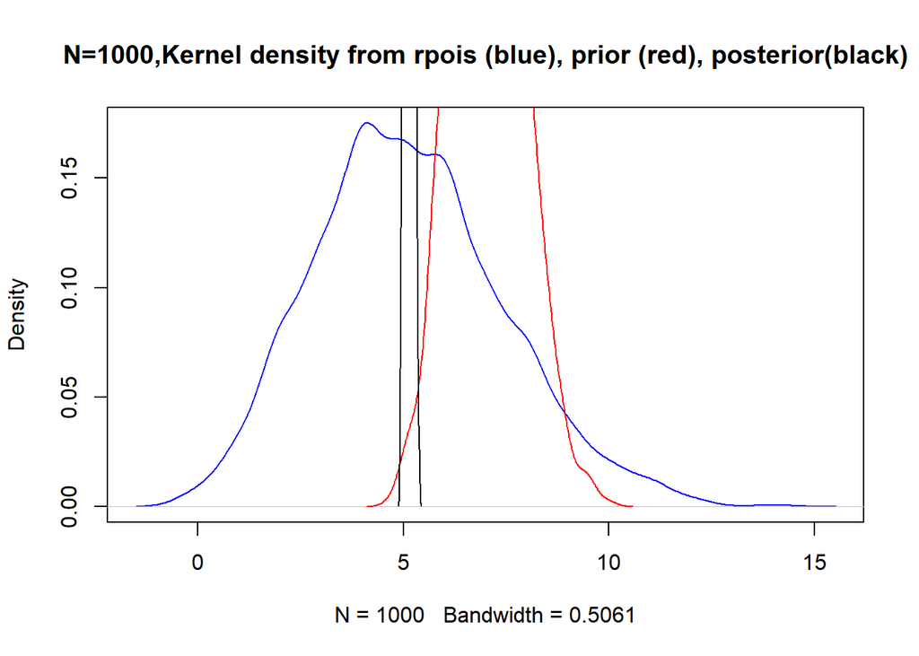

```r
#for n=1000
n<-1000
mysample1000 <- rpois(n, 5)
maxlik1000<-mean(mysample1000)
#for gamma shape is alpha and scale is beta
myprior1000 <- rgamma(n,70,10)
myposterior1000<-rgamma(n,70+(n*maxlik1000),10+n)
plot(density(mysample1000),col="blue", main = "N=1000,Kernel density from rpois (blue), prior (red), posterior(black)")
lines(density(myprior1000),col="red")
lines(density(myposterior1000),col="black")
```

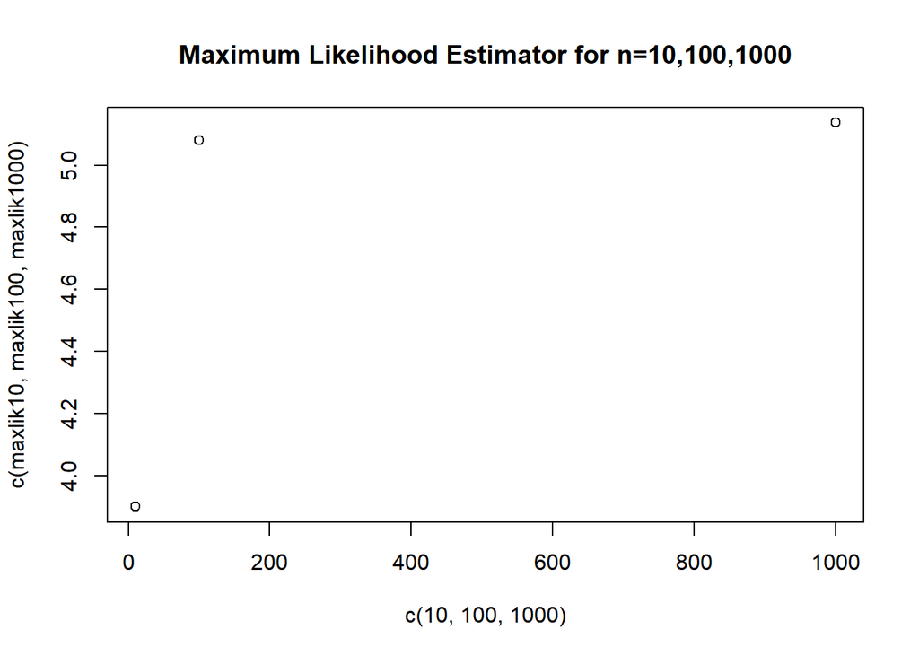

```r
plot(c(10,100,1000),c(maxlik10,maxlik100,maxlik1000),main = "Maximum Likelihood Estimator for n=10,100,1000")
```